# Practical Machine Learning - Course Project

## Introduction

### Background

Using devices such as Jawbone Up, Nike FuelBand, and Fitbit it is now possible to collect a large amount of data about personal activity relatively inexpensively. These type of devices are part of the quantified self movement – a group of enthusiasts who take measurements about themselves regularly to improve their health, to find patterns in their behavior, or because they are tech geeks. One thing that people regularly do is quantify how much of a particular activity they do, but they rarely quantify how well they do it.

## Project

In this project, we use data from accelerometers on the belt, forearm, arm, and dumbell of 6 participants. They were asked to perform barbell lifts correctly and incorrectly in 5 different ways. More information is available from the website here: http://groupware.les.inf.puc-rio.br/har (see the section on the Weight Lifting Exercise Dataset).

The goal is to predict the labels for the test set observations.

## Packages and Data

Necessary packages were loaded and also the training and testing data.

```r
library(lattice)
library(ggplot2)
library(caret)
library(randomForest)  # for prediction with random forests
ptrain <- read.csv("pml-training.csv")
ptest <- read.csv("pml-testing.csv")
```

First the training data set was randomly split the full training data into a smaller training set (ptrain1) and a validation set (ptrain2):

```r
set.seed(10)
inTrain <- createDataPartition(y=ptrain$classe, p=0.7, list=F)
ptrain1 <- ptrain[inTrain, ]
ptrain2 <- ptrain[-inTrain, ]
```

Variables with nearly zero variance, variables that are almost always NA, and variables that don’t make intuitive sense for prediction were removed.

```r
nzv <- nearZeroVar(ptrain1) # remove variables with nearly zero variance
ptrain1 <- ptrain1[, -nzv]
ptrain2 <- ptrain2[, -nzv]

mostlyNA <- sapply(ptrain1, function(x) mean(is.na(x))) > 0.95 # remove variables that are almost always NA
ptrain1 <- ptrain1[, mostlyNA==F]
ptrain2 <- ptrain2[, mostlyNA==F]

ptrain1 <- ptrain1[, -(1:5)] # remove variables that don't make intuitive sense for prediction (X, user_name, raw_timestamp_part_1, raw_timestamp_part_2, cvtd_timestamp), which happen to be the first five variables
ptrain2 <- ptrain2[, -(1:5)]
```

## Model Building

The Random Forest model was used on ptrain1, also using a 3-fold cross-validation to select optimal tuning parameters for the model.

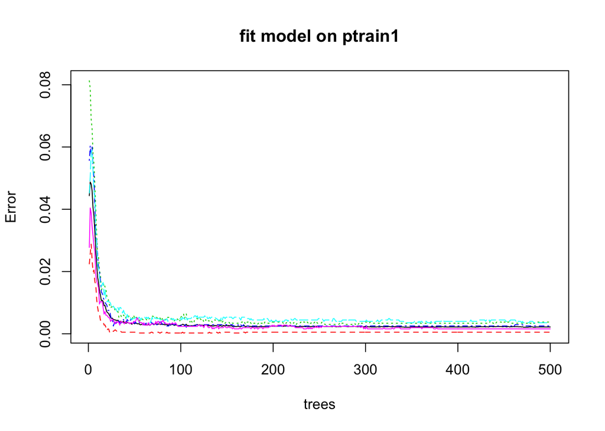

```r
fitControl <- trainControl(method="cv", number=3, verboseIter=F) #3-fold CV to select optimal tuning parameters

fit <- train(classe ~ ., data=ptrain1, method="rf", trControl=fitControl) # fit model on ptrain1
plot(fit$finalModel, main="fit model on ptrain1")
```

```r
fit$finalModel
```

```
##
## Call:
##  randomForest(x = x, y = y, mtry = param$mtry)
##                Type of random forest: classification
##                      Number of trees: 500
## No. of variables tried at each split: 27
##
##         OOB estimate of  error rate: 0.22%
## Confusion matrix:
##      A    B    C    D    E  class.error
## A 3904    1    0    0    1 0.0005120328
## B    6 2648    4    0    0 0.0037622272
## C    0    6 2390    0    0 0.0025041736
## D    0    0    7 2244    1 0.0035523979
## E    0    0    0    4 2521 0.0015841584
```

The numders of trees is 500 and the number of varibels tried at each split was 27.

## Model Evaluation and Selection

The fitted model was used to predict the label (“classe”) in ptrain2, and the confusion matrix is shown to compare the predicted versus the actual labels:

```r
preds <- predict(fit, newdata=ptrain2)
confusionMatrix(ptrain2$classe, preds)
```

```
## Confusion Matrix and Statistics
##
##           Reference
## Prediction    A    B    C    D    E
##          A 1674    0    0    0    0
##          B    3 1133    2    1    0
##          C    0    3 1023    0    0
##          D    0    0    2  962    0
##          E    0    0    0    2 1080
##
## Overall Statistics
##
##                Accuracy : 0.9978
##                  95% CI : (0.9962, 0.9988)
##     No Information Rate : 0.285
##     P-Value [Acc > NIR] : < 2.2e-16
##
##                   Kappa : 0.9972
##  Mcnemar's Test P-Value : NA
##
## Statistics by Class:
##
##                      Class: A Class: B Class: C Class: D Class: E
## Sensitivity            0.9982   0.9974   0.9961   0.9969   1.0000
## Specificity            1.0000   0.9987   0.9994   0.9996   0.9996
## Pos Pred Value         1.0000   0.9947   0.9971   0.9979   0.9982
## Neg Pred Value         0.9993   0.9994   0.9992   0.9994   1.0000
## Prevalence             0.2850   0.1930   0.1745   0.1640   0.1835
## Detection Rate         0.2845   0.1925   0.1738   0.1635   0.1835
## Detection Prevalence   0.2845   0.1935   0.1743   0.1638   0.1839
## Balanced Accuracy      0.9991   0.9980   0.9977   0.9982   0.9998
```

The accuracy is 99.8%, thus the predicted accuracy for the out-of-sample error is 0.2%.

The random forest model shows an accurate result.

## Re-training the Selected Model

Now the model is trained with the full training set (ptrain).

```r
nzv <- nearZeroVar(ptrain)
ptrain <- ptrain[, -nzv]
ptest <- ptest[, -nzv]

mostlyNA <- sapply(ptrain, function(x) mean(is.na(x))) > 0.95
ptrain <- ptrain[, mostlyNA==F]
ptest <- ptest[, mostlyNA==F]

ptrain <- ptrain[, -(1:5)]
ptest <- ptest[, -(1:5)]

fitControl <- trainControl(method="cv", number=3, verboseIter=F)
fit <- train(classe ~ ., data=ptrain, method="rf", trControl=fitControl)
```

## Making Test Set Predictions

First part is the prediction with model fit on ptrain with the ptest observations. Second part is the function to generate files with predictions to submit for assignment.

```r
preds <- predict(fit, newdata=ptest)
preds <- as.character(preds) # convert predictions to character vector

pml_write_files <- function(x) {
    n <- length(x)
    for(i in 1:n) {
        filename <- paste0("problem_id_", i, ".txt")
        write.table(x[i], file=filename, quote=F, row.names=F, col.names=F)
    }
}

pml_write_files(preds) # create prediction files to submit
```